# Project2_solution_for_big_mart

## 1. Problem Background :

The given problem is to predict the sales for a retail outlet firm. This firm has provided a year data of 10 stores in different cities. The aim is to build a predictive model and find out the sales of each product at a particular store. This big mart has collected 2013 sales data for 1559 products across 10 stores in different cities.

#### Description of Data

**Variable**

**Description**

**Item_Identifier**

Unique product ID

**Item_Weight**

Weight of product

**Item_Fat_Content**

Whether the product is low fat or not

**Item_Visibility**

The % of total display area of all products in a store allocated to the particular product

**Item_Type**

The category to which the product belongs

**Item_MRP**

Maximum Retail Price (list price) of the product

**Outlet_Identifier**

Unique store ID

**Outlet_Establishment_Year**

The year in which store was established

**Outlet_Size**

The size of the store in terms of ground area covered

**Outlet_Location_Type**

The type of city in which the store is located

**Outlet_Type**

Whether the outlet is just a grocery store or some sort of supermarket

**Item_Outlet_Sales**

Sales of the product in the particulat store. This is the outcome variable to be predicted.

[Reference Link to the problem](https://datahack.analyticsvidhya.com/contest/introduction-to-data-science-regression/)

```python
#Import statements

import pandas as pd
import numpy as np
import math
from sklearn.linear_model import LinearRegression, Ridge
from sklearn.preprocessing import PolynomialFeatures , StandardScaler
from sklearn.metrics import mean_squared_error
from sklearn.model_selection import train_test_split
from sklearn.linear_model import Lasso
from sklearn.tree import DecisionTreeRegressor
from sklearn.ensemble import AdaBoostRegressor
import seaborn as sns
import matplotlib.pyplot as plt
from sklearn.experimental import enable_iterative_imputer
from sklearn.impute import IterativeImputer
import tensorflow as tf
```

```python
#Ingestion of data
train_data=pd.read_csv("train_big_mart.csv")
test_data=pd.read_csv("test_big_mart.csv")
```

## 2. Overview of Data & Exploratory Analysis

```python
train_data.info()
```

```
<class 'pandas.core.frame.DataFrame'>
RangeIndex: 8523 entries, 0 to 8522
Data columns (total 11 columns):
Item_Weight                  7060 non-null float64
Item_Fat_Content             8523 non-null object
Item_Visibility              8523 non-null float64
Item_Type                    8523 non-null object
Item_MRP                     8523 non-null float64
Outlet_Establishment_Year    8523 non-null int64
Outlet_Size                  6113 non-null object
Outlet_Location_Type         8523 non-null object
Outlet_Type                  8523 non-null object
Item_Outlet_Sales            8523 non-null float64
ID                           8523 non-null object
dtypes: float64(4), int64(1), object(6)
memory usage: 732.6+ KB
```

> Observation:
> 1. Null values are present which need to be removed.
> 2. Item_weight will be a effective descriptor which might greatly influence the prediction. So if that may be the case, then depending how this variable is related to the item_type accordingly we will prepare the function to fill its null value.

```python
train_data.Item_Type.value_counts()
```

```
Fruits and Vegetables    1232
Snack Foods              1200
Household                 910
Frozen Foods              856
Dairy                     682
Canned                    649
Baking Goods              648
Health and Hygiene        520
Soft Drinks               445
Meat                      425
Breads                    251
Hard Drinks               214
Others                    169
Starchy Foods             148
Breakfast                 110
Seafood                    64
Name: Item_Type, dtype: int64
```

```python
df=train_data[["Item_Type","Item_Outlet_Sales"]]
df.groupby("Item_Type").sum()
```

| Item_Type | Item_Outlet_Sales |
| --- | --- |
| Baking Goods | 1.265525e+06 |
| Breads | 5.532372e+05 |
| Breakfast | 2.322990e+05 |
| Canned | 1.444151e+06 |
| Dairy | 1.522594e+06 |
| Frozen Foods | 1.825735e+06 |
| Fruits and Vegetables | 2.820060e+06 |
| Hard Drinks | 4.577934e+05 |
| Health and Hygiene | 1.045200e+06 |
| Household | 2.055494e+06 |
| Meat | 9.175656e+05 |
| Others | 3.255176e+05 |
| Seafood | 1.488682e+05 |
| Snack Foods | 2.732786e+06 |
| Soft Drinks | 8.928977e+05 |
| Starchy Foods | 3.514013e+05 |

```python
df=train_data[["Item_Type","Item_Outlet_Sales","Item_Weight"]]
df=df[df.Item_Type=="Snack Foods"]
df.groupby("Item_Weight").mean()
```

| Item_Weight | Item_Outlet_Sales |
| --- | --- |
| 5.095 | 1770.09588 |
| 5.175 | 2064.31290 |
| 5.340 | 1658.84070 |
| 5.590 | 937.44640 |
| 5.675 | 2121.23880 |
| ... | ... |
| 20.750 | 2188.48460 |
| 20.850 | 2479.43920 |
| 21.000 | 1194.77810 |
| 21.200 | 2999.42900 |
| 21.250 | 2301.00480 |

139 rows × 1 columns

```python
len(train_data["Item_Weight"].unique())
```

```
416
```

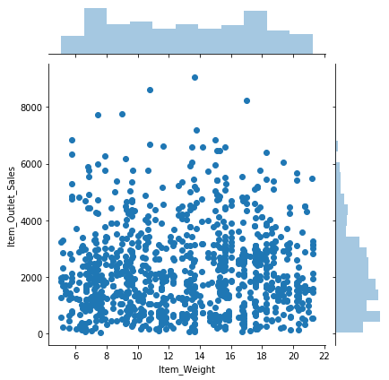

```python
sns.jointplot(x='Item_Weight',y='Item_Outlet_Sales' , data=df)
```

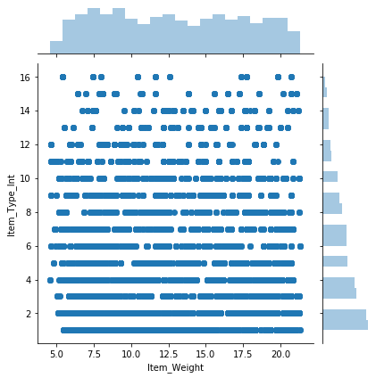

```python
##checking how weights are distributed in each category
df=train_data[["Item_Type","Item_Fat_Content", "Item_Weight"]]
z=list(df["Item_Type"].value_counts().keys())
a=list(range(1,len(z)+1))
q=dict(list(zip(z,a)))
df['Item_Type_Int']=[q[i] for i in df['Item_Type']]
sns.jointplot(x='Item_Weight', y='Item_Type_Int' , data=df)
```

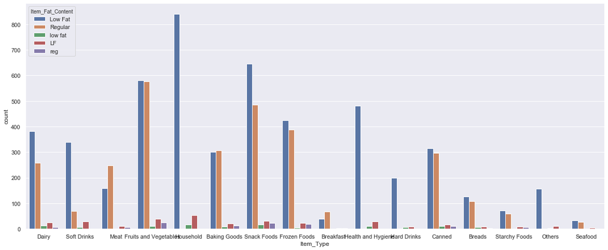

```python
df=train_data[["Item_Type","Item_Fat_Content", "Item_Weight"]]
sns.set(style="darkgrid")
fig, ax1 = plt.subplots(figsize=(20,8))
ax = sns.countplot(x="Item_Type", hue="Item_Fat_Content", ax=ax1,data=df)
plt.show()
```

> Observation:
> 1. Item_Fat_content has some inconsitent types for representation for the each specific kind. Based on description, it should had only only two type of values i.e regular or Low Fat. This need to be handled in cleaning

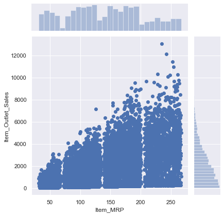

```python
#checking Item_MRP
df=train_data[["Item_MRP", "Item_Outlet_Sales"]]
sns.jointplot(x="Item_MRP", y="Item_Outlet_Sales", data=df)
```

> Observation:
> 1. MRP seems co-orelated with the output_sales. It will be kept in the analysis

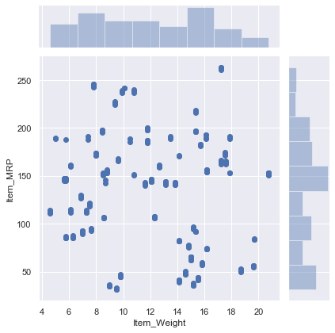

```python
#checking if Item_Weight & Item_MRP are co-related
df=train_data[["Item_Type","Item_Fat_Content","Item_Weight","Item_MRP"]]
a=df.Item_Type=="Soft Drinks"
b=df.Item_Fat_Content=="Low Fat"
df=df[a & b]
sns.jointplot(x="Item_Weight", y="Item_MRP" ,data=df )
```

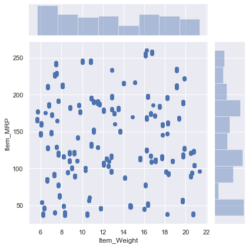

```python
df=train_data[["Item_Type","Item_Fat_Content","Item_Weight","Item_MRP"]]
a=df.Item_Type=="Fruits and Vegetables"
b=df.Item_Fat_Content=="Low Fat"
df=df[a & b]
sns.jointplot(x="Item_Weight", y="Item_MRP" ,data=df )
```

> Observation :
> 1. Item MRP & Item weight doesn't appear to be co-related within same category & same fat_content_type.
> 2. Item_weight doesn't seems that distributed. So the assertion of using item_weight as categorical variable still holds true.

```python
df=train_data[["Outlet_Establishment_Year", "Outlet_Size", "Outlet_Location_Type", "Outlet_Type"]]
df.groupby(["Outlet_Establishment_Year", "Outlet_Size", "Outlet_Location_Type", "Outlet_Type"]).count()
```

| Outlet_Establishment_Year | Outlet_Size | Outlet_Location_Type | Outlet_Type |
| --- | --- | --- | --- |
| 1985 | Medium | Tier 3 | Supermarket Type3 |
|  | Small | Tier 1 | Grocery Store |
| 1987 | High | Tier 3 | Supermarket Type1 |
| 1997 | Small | Tier 1 | Supermarket Type1 |
| 1999 | Medium | Tier 1 | Supermarket Type1 |
| 2004 | Small | Tier 2 | Supermarket Type1 |
| 2009 | Medium | Tier 3 | Supermarket Type2 |

> Observation:
> 1. There are not multiple types of location defined in the descriptors which are related to the outlet i.e only 7 variations are available in outlet types.
> 2. These locations can be combined in to the onve variable with 7 categorical cable.

```python
# Quick Check on cases of NA in outlet type descriptors
train_data[train_data.Outlet_Size.isna()][["Outlet_Establishment_Year","Outlet_Size","Outlet_Location_Type","Outlet_Type"]].fillna(1).groupby(["Outlet_Establishment_Year","Outlet_Size","Outlet_Location_Type", "Outlet_Type"]).count()
```

| Outlet_Establishment_Year | Outlet_Size | Outlet_Location_Type | Outlet_Type |
| --- | --- | --- | --- |
| 1998 | 1 | Tier 3 | Grocery Store |
| 2002 | 1 | Tier 2 | Supermarket Type1 |
| 2007 | 1 | Tier 2 | Supermarket Type1 |

```python
#Check on cases of NA in weight
train_data[train_data.Item_Weight.isna()][["Item_Fat_Content","Item_Type"]].groupby(["Item_Fat_Content","Item_Type"]).count()
```

| Item_Fat_Content | Item_Type |
| --- | --- |
| LF | Baking Goods |
|  | Breads |
|  | Canned |
|  | Dairy |
|  | Frozen Foods |
|  | Fruits and Vegetables |
|  | Hard Drinks |
|  | Health and Hygiene |
|  | Household |
|  | Meat |
|  | Others |
|  | Snack Foods |
|  | Soft Drinks |
|  | Starchy Foods |
| Low Fat | Baking Goods |
|  | Breads |
|  | Breakfast |
|  | Canned |
|  | Dairy |
|  | Frozen Foods |
|  | Fruits and Vegetables |
|  | Hard Drinks |
|  | Health and Hygiene |
|  | Household |
|  | Meat |
|  | Others |
|  | Seafood |
|  | Snack Foods |
|  | Soft Drinks |
|  | Starchy Foods |
| Regular | Baking Goods |
|  | Breads |
|  | Breakfast |
|  | Canned |
|  | Dairy |
|  | Frozen Foods |
|  | Fruits and Vegetables |
|  | Meat |
|  | Seafood |
|  | Snack Foods |
|  | Soft Drinks |
|  | Starchy Foods |
| low fat | Baking Goods |
|  | Breads |
|  | Canned |
|  | Dairy |
|  | Fruits and Vegetables |
|  | Hard Drinks |
|  | Health and Hygiene |
|  | Household |
|  | Others |
|  | Snack Foods |
|  | Soft Drinks |
| reg | Baking Goods |
|  | Canned |
|  | Dairy |
|  | Frozen Foods |
|  | Snack Foods |
|  | Starchy Foods |

> Observations:
> 1. Missing values in weight column need to be imputed using iterative imputer from scikit taking input from rest item descriptor columns
> 2. Missing values in Outlet size will be imputed using the simple imputation from scikit using the mean strategy.

#### **Inferences from Exploratory Analysis** :

1. The data is in straightforward fashion collected in form of table. For each line (row) there are some decriptors like item_weight, item_fat_content & item_Visibility to provide descriptive attributes about each item_type. Plus the sales of that item_type is dependent on that outlet whose descriptors are outlet_size & establishment_year & Location type.
2. The data cleaning is required to accomodate the missing data in item_weight & outlet_type as well repairing the inconsistent values in column Fat_content_type
3. Column "Item_Weight" will be tried out as numerical variable as well in other model as categorical variable
4. Outlet_Establishment_Year, Outlet_Size, Outlet_Location_Type, Outlet_Type will be merged into a single categorical variable "Outlet" as they seem to denote the same variable.
5. Numerical variable will be Outlet_sales , Item_weight, Item_MRP rest will be treated as categorical variable.
6. Basic cleaming & pre-processing will be used and linear model will be used to create the threshold benchmark for acceptance on the model performance.
7. With Advanced cleaning and pre-processing, other models will be developed which are better than linear model performance and best performing model will be used for predicting the result.

### Preparation for cleaning, pre-processing & setting the selection benchmark

```python
#defining helper class, function for structuring data and ML models
class data_model():
    def __init__(self,data,d_type, **kwargs):
        l1=list()
        self.scaler=None
        self.poly=kwargs.pop("poly", None)
        self.poly_func=kwargs.pop("poly_func", None)
        for key in kwargs:
            #self.key=data[kwargs[key]]
            setattr(self,key,data[kwargs[key]])
            #print(key,kwargs[key])
            l1.append(kwargs[key])
        self.data=data.drop(columns=l1)
        self.model=None
        self.scaled=None
        self.type=d_type
    #add scaler function to the data to keep track of it
    def add_scaler(self,scalerfunc):
        self.scaler=scalerfunc
        self.scaled=0
    #function to check the scaler function & return it.
    def get_scaler(self):
        if self.scaler == None :
            raise ValueError ("scaler function doesn't exist")
        return self.scaler
    def fit_scaler(self):
        scaler=self.get_scaler()
        scaler.fit(self.data[["Item_Weight","Item_Visibility","Item_MRP"]])
    #function to scale the values in the data to same range the data
    def scale_model(self):
        scaler=self.get_scaler()
        if self.scaled ==1:
            return self.data
        else:
            self.data[["Item_Weight","Item_Visibility","Item_MRP"]]= \
            scaler.transform(self.data[["Item_Weight","Item_Visibility","Item_MRP"]])
            self.scaled=1
            return self.data
    #function to provide the data for prediction
    def get_predict_data(self):
        if self.poly_func:
            data=self.poly_func.transform(self.data)
        else :
            data=self.data
        return data
    #function to provide the data for training
    def get_train_data(self,d_type):
        if d_type == "train" :
            data=self.data
            if self.poly:
                setattr(self,"poly_func",PolynomialFeatures(self.poly))
                data=self.poly_func.fit_transform(data)
            X_train, X_test, y_train, y_test, train_ID, test_ID = train_test_split(data,
                                                               self.result,
                                                                self.UID,
                                                               test_size=0.2, random_state=43)
            return X_train, X_test, y_train, y_test


#function to run the model to train or predict from the data
def run_model(data_model, m_type, mode="predict"):
    data=data_model.scale_model()
    model=get_model(data,m_type=m_type)
    if mode=="train" :
        X_train, X_test,Y_train, Y_test= data_model.get_train_data(d_type=mode)
        if m_type=="tf":
            model.fit(X_train.values, Y_train.values, epochs=600)
        if m_type=="tf":
            results=model.evaluate(X_train.values,Y_train.values)
            model.train_error=math.sqrt(results[1])
            print("Validation error is")
            results=model.evaluate(X_test.values,Y_test.values, verbose=2)
            model.test_error=math.sqrt(results[1])
        else:
            model.fit(X_train,Y_train)
            model.train_error=get_error_function(Y_train,model.predict(X_train))
            model.test_error=get_error_function(Y_test,model.predict(X_test))
            print("Train error is ", get_error_function(Y_train,model.predict(X_train)))
            print("Validation error is ", get_error_function(Y_test,model.predict(X_test)))

    if mode=="predict":
        return model.predict(data_model.get_predict_data())
    return model


#function to save the model types and to be called upon runtime
def get_model(data,m_type):
    if m_type=="lasso":
        model=Lasso(alpha=100)
        return model
    elif m_type=="linear":
        model=LinearRegression()
        return model
    elif m_type=="DTR":
        model=DecisionTreeRegressor(min_samples_leaf=5,random_state=42)
        return model
    elif m_type=="Ada":
        model=AdaBoostRegressor(random_state=42,n_estimators=1000, learning_rate=0.1, loss="square")
        return model
    elif m_type=="Ridge":
        model=Ridge(alpha=300, random_state=21)
        return model
    elif m_type=="Ridge-P":
        #poly=PolynomialFeatures(4)
        #data=poly.fit_transform(data)
        model=Ridge(alpha=10,random_state=21)
        return model
    elif m_type=="linear-p":
        #poly=PolynomialFeatures(3)
        #data=poly.fit_transform(data)
        #print(data.shape,"during additional polynomials")
        model=LinearRegression()
        return model
    elif m_type=="tf":
        model=tf.keras.models.Sequential([
        tf.keras.layers.Dense(512,input_shape=(32,),activation= "relu", kernel_initializer='normal'),
        tf.keras.layers.Dropout(0.2),
        tf.keras.layers.Dense(128, activation= "relu", kernel_initializer='normal'),
        tf.keras.layers.Dropout(0.2),
        tf.keras.layers.Dense(64, activation= "relu", kernel_initializer='normal'),
        tf.keras.layers.Dense(1,)
        ])
        model.compile(optimizer="adam",
                      loss="mse",
                      metrics=["mean_squared_error"])
        return model
    else :
        raise ValueError("Model code doesn't exist")

def get_error_function(y, pred):
    return math.sqrt(mean_squared_error(y,pred))
```

```python
#building basic cleaning data function
def clean_data_basic (data):

    #cleaningsteps
    #Removing Nan entries from Item_Weight Column
    data.Item_Weight=data.Item_Weight.fillna(0)

    #Storing index keys into external object
    keys=list(data.keys())

    # Creating Variables to utilize them during processing
    Categorical_index=[1,3,5,6,7,8]
    category_integer=Categorical_index[2]
    continuous_data=[0,2,4]

    #condition to handle the submission result as it doesn't have any output_sales column
    if "Item_Outlet_Sales" in keys :
        Output_index=9
        id_index=10
    else :
        id_index=9
        Output_index=None

    #creating one_hot_encoding for categorical data
    data=pd.get_dummies(data, dummy_na=True)

    return data
```

```python
#trying case 1 to prepare the benchmark
train_d=train_data.copy()
train_d1=data_model(data=train_d,d_type="train", UID="ID", result="Item_Outlet_Sales" )
train_d1.data=clean_data_basic(train_d1.data)
train_d1.add_scaler(StandardScaler())
train_d1.fit_scaler()
run_model(train_d1,m_type="linear", mode="train")
```

```
Train error is  1130.8405587617503
Validation error is  1113.5038187228868
```

```
LinearRegression(copy_X=True, fit_intercept=True, n_jobs=None, normalize=False)
```

### observation :

> 1. RMS error from the linear model comes out to be the 1113 for validation set.
> 2. This rms error will act as benchmark for selection of the the final model .

### function to pre-process the function based on exploratory analysis

```python
#building basic cleaning data function
def process_clean_data (data_model,*args):
    #cleaningsteps
    #irregular terms (eg: LF) to standard respresentatitve terms (eg: Low Fat)
    data_model.data["Item_Fat_Content"][data_model.data["Item_Fat_Content"]=="LF"]="Low Fat"
    data_model.data["Item_Fat_Content"][data_model.data["Item_Fat_Content"]=="reg"]="Regular"
    data_model.data["Item_Fat_Content"][data_model.data["Item_Fat_Content"]=="low fat"]="Low Fat"
    '''#Merging Outlet desriptors into one column
    outlet_descriptors= ["Outlet_Type", "Outlet_Size","Outlet_Establishment_Year","Outlet_Location_Type"]
    temp=np.empty(data_model.data[outlet_descriptors].shape)
    for idx,item in enumerate(outlet_descriptors):
        labels = factorize_custom(series=data_model.data[item],name=item)
        temp[:,idx]=labels
    temp=temp.astype("U1")
    column=list()
    for items in temp:
        sep=""
        sep=sep.join(items)
        column.append(sep)
    data_model.data["Outlet_Code"]=column
    data_model.data=data_model.data.drop(columns=outlet_descriptors)'''

    #Removing Nan entries from Item_Weight Column
    if args==():
        imp=IterativeImputer(max_iter=10,random_state=42, initial_strategy="mean")
    else:
        imp=args[0]
    data_x =weight_imputation(data_model, imp)
    data_model.imp=imp
    data_model.data=data_x



    #Storing index keys into external object
    #keys=list(data.keys())

    # Creating Variables to utilize them during processing
    #Categorical_index=[1,3,5,6,7,8]
    #category_integer=Categorical_index[2]
    #continuous_data=[0,2,4]

    #condition to handle the submission result as it doesn't have any output_sales column
    #if "Item_Outlet_Sales" in keys :
    #    Output_index=9
    #    id_index=10
    #else :
    #    id_index=9
    #    Output_index=None

    #creating one_hot_encoding for categorical data
    data_model.data=pd.get_dummies(data_model.data, dummy_na=False)

    return data_model


def get_list_dict():
    list_dict={"Outlet_Type": ['Supermarket Type1', 'Supermarket Type2', 'Grocery Store','Supermarket Type3'],
           "Outlet_Size": ['Medium', 'High', 'Small', np.nan],
           "Outlet_Establishment_Year" : [1999, 2009, 1998, 1987, 1985, 2002, 2007, 1997, 2004],
           "Outlet_Location_Type" : ['Tier 1', 'Tier 3', 'Tier 2']}
    return list_dict


#function to convert string into desired numeric for caategory aggregation:
def factorize_custom(series,name):
    list_dict=get_list_dict()
    if name in list_dict:
        temp_list=list_dict[name]
        return series.apply(lambda x : temp_list.index(x))

def weight_imputation(data_model, imp):
    data_x=data_model.data.copy()
    item_list=["Item_Weight","Item_Fat_Content","Item_Type"]
    roll_list= ["Item_Fat_Content","Item_Type"]
    data_x[roll_list]=integerize_items(data_x[roll_list])
    #for idx,item in enumerate(data_x[item_list].drop(columns=["Item_Weight"]).columns):
    #    categ=data_x[item].astype("category").cat.categories
    #    categ_list.append(categ)
    #    categ_index=list(range(len(categ)))
    #    data_x[item]=data_x[item].astype("category").cat.rename_categories(categ_index)
    imp.fit(data_x[item_list][~data_model.data.Item_Weight.isna()])
    data_x[item_list]=imp.transform(data_x[item_list])
    data_x[roll_list]=de_integerize(data_x[roll_list])
    #for idx,item in enumerate(data_x[item_list].drop(columns=["Item_Weight"]).columns):
    #    data_x[item]=data_x[item].astype("category").cat.rename_categories(categ_list[idx])
    return data_x

def integerize_items(data):
    col_list=["Item_Fat_Content","Item_Type"]
    list_dict={"Item_Fat_Content": ['Low Fat', 'Regular'], "Item_Type":['Baking Goods', 'Breads', 'Breakfast', 'Canned', 'Dairy',
        'Frozen Foods', 'Fruits and Vegetables', 'Hard Drinks',
        'Health and Hygiene', 'Household', 'Meat', 'Others', 'Seafood',
        'Snack Foods', 'Soft Drinks', 'Starchy Foods']}
    temp=pd.DataFrame()
    for items in list_dict:
        temp[items]=data[items].transform(lambda x : list_dict[items].index(x))
    return temp

def de_integerize(data):
    col_list=["Item_Fat_Content","Item_Type"]
    list_dict={"Item_Fat_Content": ['Low Fat', 'Regular'], "Item_Type":['Baking Goods', 'Breads', 'Breakfast', 'Canned', 'Dairy',
        'Frozen Foods', 'Fruits and Vegetables', 'Hard Drinks',
        'Health and Hygiene', 'Household', 'Meat', 'Others', 'Seafood',
        'Snack Foods', 'Soft Drinks', 'Starchy Foods']}
    temp=pd.DataFrame()
    for items in list_dict:
        temp[items]=data[items].transform(lambda i : list_dict[items][int(i)] )
    return temp
```

#### Test out of different model types to find the best suitable for problem

```python
# trying lasso class to build model
train_d=train_data.copy()
train_d1=data_model(data=train_d,d_type="train", UID="ID", result="Item_Outlet_Sales" )
train_d1=process_clean_data(train_d1)
train_d1.add_scaler(StandardScaler())
train_d1.fit_scaler()
run_model(train_d1,m_type="lasso", mode="train")
```

```
Train error is  1217.549423504012
Validation error is  1177.234742905177
```

```
Lasso(alpha=100, copy_X=True, fit_intercept=True, max_iter=1000,
      normalize=False, positive=False, precompute=False, random_state=None,
      selection='cyclic', tol=0.0001, warm_start=False)
```

```python
#trying DecisionTreeClassifier
train_d=train_data.copy()
train_d1=data_model(data=train_d,d_type="train", UID="ID", result="Item_Outlet_Sales" )
train_d1=process_clean_data(train_d1)
train_d1.add_scaler(StandardScaler())
train_d1.fit_scaler()
run_model(train_d1,m_type="DTR", mode="train")
```

```
Train error is  792.5505980329667
Validation error is  1272.7989483539905
```

```
DecisionTreeRegressor(criterion='mse', max_depth=None, max_features=None,
                      max_leaf_nodes=None, min_impurity_decrease=0.0,
                      min_impurity_split=None, min_samples_leaf=5,
                      min_samples_split=2, min_weight_fraction_leaf=0.0,
                      presort=False, random_state=42, splitter='best')
```

```python
#trying AdaBoostRegressor
train_d=train_data.copy()
train_d1=data_model(data=train_d,d_type="train", UID="ID", result="Item_Outlet_Sales" )
train_d1=process_clean_data(train_d1)
train_d1.add_scaler(StandardScaler())
train_d1.fit_scaler()
run_model(train_d1,m_type="Ada", mode="train")
```

```
Train error is  1507.3545178570223
Validation error is  1517.8842138993384
```

```
AdaBoostRegressor(base_estimator=None, learning_rate=0.1, loss='square',
                  n_estimators=1000, random_state=42)
```

```python
#trying Ridge Regressor
train_d=train_data.copy()
train_d1=data_model(data=train_d,d_type="train", UID="ID", result="Item_Outlet_Sales" )
train_d1=process_clean_data(train_d1)
train_d1.add_scaler(StandardScaler())
train_d1.fit_scaler()
run_model(train_d1,m_type="Ridge", mode="train")
```

```
Train error is  1203.1003715759311
Validation error is  1171.1285898040117
```

[output not shown]

```python
#DNN model from tensorflow
train_d=train_data.copy()
train_d1=data_model(data=train_d,d_type="train", UID="ID", result="Item_Outlet_Sales" )
train_d1=process_clean_data(train_d1)
train_d1.add_scaler(StandardScaler())
train_d1.fit_scaler()
model=run_model(train_d1,m_type="tf", mode="train")
```

```
Train on 6818 samples
Validation error is
1705/1 - 1s - loss: 753822.0952 - mean_squared_error: 1221380.8750
```

```python
#creating submission file
test_data=pd.read_csv("test_big_mart.csv")
test_d=data_model(data=test_data,d_type="test",UID="ID")
test_d=process_clean_data(test_d)
test_d.add_scaler(train_d1.scaler)
data=test_d.scale_model()
model.predict(data)
f=pd.DataFrame(list(test_d.UID),columns=["ID"])
f["Item_Outlet_Sales"]=model.predict(data)
f.to_csv("submission_tf_new.csv", header=True, index=False)
```

```python
# testpad 1
train_d=train_data.copy()
train_d1=data_model(data=train_d,d_type="train", UID="ID", result="Item_Outlet_Sales", poly=3 )
train_d1.data=clean_data_basic(train_d1.data)
train_d1.add_scaler(StandardScaler())
train_d1.fit_scaler()
model=run_model(train_d1,m_type="linear-p", mode="train")

#testpad submission
test_data=pd.read_csv("test_big_mart.csv")
test_d=data_model(data=test_data,d_type="test",UID="ID", poly_func=train_d1.poly_func)
test_d.data=clean_data_basic(test_d.data)
test_d.add_scaler(train_d1.scaler)
data=test_d.scale_model()
f=pd.DataFrame(list(test_d.UID),columns=["ID"])
f["Item_Outlet_Sales"]=model.predict(test_d.get_predict_data())
f.to_csv("submission_linear_new.csv", header=True, index=False)
```

[output not shown]

```python
# testpad 2
train_d=train_data.copy()
train_d1=data_model(data=train_d,d_type="train", UID="ID", result="Item_Outlet_Sales", poly=3)
train_d1=process_clean_data(train_d1)
train_d1.add_scaler(StandardScaler())
train_d1.fit_scaler()
model=run_model(train_d1,m_type="lasso", mode="train")

#testpad submission
test_data=pd.read_csv("test_big_mart.csv")
test_d=data_model(data=test_data,d_type="test",UID="ID", poly_func=train_d1.poly_func)
test_d=process_clean_data(test_d,train_d1.imp)
test_d.add_scaler(train_d1.scaler)
data=test_d.scale_model()
f=pd.DataFrame(list(test_d.UID),columns=["ID"])
f["Item_Outlet_Sales"]=model.predict(test_d.get_predict_data())
f.to_csv("submission_lass_trial.csv", header=True, index=False)
```

```
Train error is  1061.0012583573869
Validation error is  1060.242644681671
```

```python
# testpad 3
train_d=train_data.copy()
train_d1=data_model(data=train_d,d_type="train", UID="ID", result="Item_Outlet_Sales")
train_d1=process_clean_data(train_d1)
train_d1.add_scaler(StandardScaler())
train_d1.fit_scaler()
model=run_model(train_d1,m_type="tf", mode="train")

#testpad submission
test_data=pd.read_csv("test_big_mart.csv")
test_d=data_model(data=test_data,d_type="test",UID="ID", poly_func=train_d1.poly_func)
test_d=process_clean_data(test_d,train_d1.imp)
test_d.add_scaler(train_d1.scaler)
data=test_d.scale_model()
f=pd.DataFrame(list(test_d.UID),columns=["ID"])
f["Item_Outlet_Sales"]=model.predict(test_d.get_predict_data().values)
f.to_csv("submission_tf_trial.csv", header=True, index=False)
```

```
Train on 6818 samples
Validation error is
1705/1 - 1s - loss: 1409562.4413 - mean_squared_error: 1422582.1250
```

### Plotting the results

> Comparing the errors in each of the function and selecting the model with the least error.

```python
when=list([1,2])
feel=dict({"state":when})
error_values=pd.Series(when ,index= ["upper", "lower"])
total_error=pd.DataFrame()
total_error["insight"]=error_values
```

```python
total_error
```

|  | insight |
| --- | --- |
| upper | 1 |
| lower | 2 |

```python
# function to plot the error values in prediction by each of the model
function_errors=pd.DataFrame()
model_list= {"linear":None, "lasso": 3, "DTR": None, "Ada": None, "Ridge": 3, "tf" : None }
for items in model_list:
    train_d=train_data.copy()
    train_d1=data_model(data=train_d,d_type="train", UID="ID", result="Item_Outlet_Sales", poly=model_list[items])
    train_d1=process_clean_data(train_d1)
    train_d1.add_scaler(StandardScaler())
    train_d1.fit_scaler()
    model=run_model(train_d1,m_type=items, mode="train")
    error_temp=list()
    error_temp.append(model.train_error)
    error_temp.append(model.test_error)
    error_values=pd.Series(error_temp,index=["train_error", "validation_error"])
    function_errors[items]=error_values
```

```
Train error is  1132.4379739115466
Validation error is  1107.6150673924244
```

```
Train error is  1061.0012583573869
Validation error is  1060.242644681671
```

```
Train error is  791.0376294038471
Validation error is  1287.5151116805814
```

```
Train error is  1439.677481620345
Validation error is  1438.3564239614739
```

```
Train error is  1038.383396672984
Validation error is  1076.294991905522
```

```
Train on 6818 samples
Validation error is
1705/1 - 1s - loss: 1250633.9715 - mean_squared_error: 1312816.0000
```

```python
function_errors
```

|  | linear | lasso | DTR | Ada | Ridge | tf |
| --- | --- | --- | --- | --- | --- | --- |
| train_error | 1132.437974 | 1061.001258 | 791.037629 | 1439.677482 | 1038.383397 | 1183.826370 |
| validation_error | 1107.615067 | 1060.242645 | 1287.515112 | 1438.356424 | 1076.294992 | 1145.781829 |

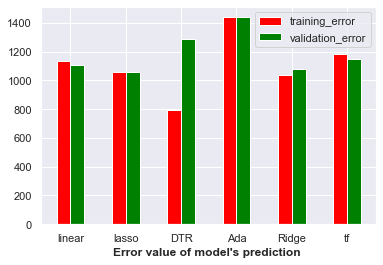

```python
barWidth=0.25
r=list(range(3))
r[0] = np.arange(len(function_errors.iloc[0]))
r[1] = [x + barWidth for x in r1]
r[2]= [x + barWidth for x in r2]
plt.bar(r[0],function_errors.iloc[0], color="red", width=barWidth, label="training_error")
plt.bar(r[1],function_errors.iloc[1],color="green", width=barWidth, label="validation_error")
plt.xlabel("Error value of model's prediction ", fontweight="bold")
plt.xticks([barWidth/2 +x for x in range(len(function_errors.iloc[0]))],function_errors.columns)
plt.legend()
plt.show()
```

> Observation:
> 1. Out of the models tried to predict the sales, lasso and ridge model are performing with the least mse (error).
> 2. Best on submission of the model to the unseen test results, lasso model is selected as the most suitable

> Observation
> 1. The performance of lasso was also verified based on its better performance on the test results of unknown data.
> 2. snapshots of results :

[figure not shown]

```python
#average value of outlet sales in validation set is
y_test.mean()
```

```
2118.5189777126097
```

### Additional Materials

References:

1. https://python-graph-gallery.com/11-grouped-barplot/
2. https://machinelearningmastery.com/regression-tutorial-keras-deep-learning-library-python/

Problem site : https://datahack.analyticsvidhya.com/contest/introduction-to-data-science-regression/